# Algoritma FP-Growth dengan R

Tantri Novita Sari-Institut Teknologi Statistika dan Bisnis Muhammadiyah

2023-01-19

# Algoritma FP-Growth

## Definisi

FP-Growth adalah salah satu alternatif algoritma yang dapat digunakan untuk menentukan himpunan data yang paling sering muncul (frequent itemset) dalam sebuah kumpulan data (Indah Mulia Sari : 2013).

FP-Growth adalah algoritma pencarian frequent item sets yang didapat dari FP-tree dengan menjelajahi tree dari bawah menuju ke atas (Tan, Steinbach, & Kumar, 2004).

FP-growth adalah salah satu alternatif algoritma yang dapat digunakan untuk menentukan himpunan data yang paling sering muncul (frequent itemset) dalam sebuah kumpulan data.

FP-growth menggunakan pendekatan yang berbeda dari paradigma yang digunakan pada algoritma Apriori (Sensuse, 2012).

FP-Growth adalah algoritma pencarian frequent itemsets yang didapat dari FP-tree (Rama Novta Miraldi, 2014).

Jadi dapat disimpulkan bahwa FP-Growth adalah salah satu algoritma yang digunakan untuk mencari himpunan data yang sering muncul dari sekumpulan data, dengan menggunakan cara pembangktan stuktur data Tree.

## Tujuan

Tujuan dari algoritma FP-Growth adalah sama dengan Apriori yaitu mencari Association Rules (hubungan antar item di dalam sebuah dataset yang telah ditentukan)

## Kelebihan Algoritma FP-Growth

FP-Growth merupakan algoritma yang lebih baik dibandingkan dengan algoritma apriori dikarenakan algoritma apriori yang memakan waktu saat menentukan kandidat itemset dan membaca database yang berulang-ulang, sedangkan FP-Growth hanya membaca database satu kali saat pembuatan FP-Tree dan menggunakan kandidat itemset dalam proses pembentukan frequent pattern.

# Tahapan Algoritma FP-Growth

1. Siapkan Dataset
2. Pengurutan berdasarkan nilai frekuensi kemunculan item yang terbesar
3. Membentuk FP-tree
4. Membentuk Conditional Pattern Base
5. Membentuk Conditional FP-tree
6. Membentuk Frequent Pattern Generated
7. Mencari frequency 2 Itemset
8. Mencari Support 2 Itemset 9 Mencari Confidance 2 Itemset

# Eksperimen Algoritma

## library

```r
if(sessionInfo()['basePkgs']=="dplyr" | sessionInfo()['otherPkgs']=="dplyr"){
  detach(package:dplyr, unload=TRUE)
}

if(sessionInfo()['basePkgs']=="tm" | sessionInfo()['otherPkgs']=="tm"){
  detach(package:sentiment, unload=TRUE)
  detach(package:tm, unload=TRUE)
}

library(plyr)
library(arules)
```

```r
library(arulesViz)
library(Matrix)
library(base)
```

## Masukkan Dataset

```r
groceries <- readxl:: read_excel("~/Semester 3/Data Mining/Groceries_dataset.xlsx")
class(groceries)
```

```
## [1] "tbl_df"     "tbl"        "data.frame"
```

## Pembersihan Data dan Eksplor

```r
str(groceries)
```

```
## tibble [38,765 × 3] (S3: tbl_df/tbl/data.frame)
##  $ Member_number  : num [1:38765] 1808 2552 2300 1187 3037 ...
##  $ Date           : chr [1:38765] "21-07-2015" "42125" "19-09-2015" "42350" ...
##  $ itemDescription: chr [1:38765] "tropical fruit" "whole milk" "pip fruit" "other vegetables" ...
```

```r
head(groceries)
```

```
## # A tibble: 6 × 3
##   Member_number Date       itemDescription
##           <dbl> <chr>      <chr>
## 1          1808 21-07-2015 tropical fruit
## 2          2552 42125      whole milk
## 3          2300 19-09-2015 pip fruit
## 4          1187 42350      other vegetables
## 5          3037 42006      whole milk
## 6          4941 14-02-2015 rolls/buns
```

## Mengecek Nilai NA

```r
sum(is.na(groceries))
```

```
## [1] 0
```

```r
sorted <- groceries[order(groceries$Member_number),]
```

```r
sorted$Member_number <- as.numeric(sorted$Member_number)
str(sorted)
```

```
## tibble [38,765 × 3] (S3: tbl_df/tbl/data.frame)
##  $ Member_number  : num [1:38765] 1000 1000 1000 1000 1000 1000 1000 1000 1000 1000 ...
##  $ Date           : chr [1:38765] "27-05-2015" "24-07-2015" "15-03-2015" "25-11-2015" ...
##  $ itemDescription: chr [1:38765] "soda" "canned beer" "sausage" "sausage" ...
```

## Kelompokkan semua item yang dibeli bersama oleh pelanggan yang sama pada tanggal yang sama

```r
itemList <- ddply(sorted, c("Member_number","Date"), function(df1)paste(df1$itemDescription,collapse = ","))

head(itemList,15)
```

```
##    Member_number       Date                                            V1
## 1           1000 15-03-2015 sausage,whole milk,semi-finished bread,yogurt
## 2           1000 24-06-2014                 whole milk,pastry,salty snack
## 3           1000 24-07-2015                   canned beer,misc. beverages
## 4           1000 25-11-2015                      sausage,hygiene articles
## 5           1000 27-05-2015                       soda,pickled vegetables
## 6           1001 14-04-2015                              beef,white bread
## 7           1001 20-01-2015           frankfurter,soda,whipped/sour cream
## 8           1001      41822                 sausage,whole milk,rolls/buns
## 9           1001      41985                               whole milk,soda
## 10          1001      42040                              frankfurter,curd
## 11          1002 26-04-2014                             butter,whole milk
## 12          1002 26-04-2015                          tropical fruit,sugar
## 13          1002 30-08-2015               butter milk,specialty chocolate
## 14          1002      41884            frozen vegetables,other vegetables
## 15          1003 15-10-2014                     root vegetables,detergent
```

## Menghapus nomor dan tanggal anggota

```r
itemList$Member_number <- NULL
itemList$Date <- NULL
colnames(itemList) <- c("itemList")
```

```r
write.csv(itemList,"ItemList.csv", quote = FALSE, row.names = TRUE)
head(itemList)
```

```
##                                        itemList
## 1 sausage,whole milk,semi-finished bread,yogurt
## 2                 whole milk,pastry,salty snack
## 3                   canned beer,misc. beverages
## 4                      sausage,hygiene articles
## 5                       soda,pickled vegetables
## 6                              beef,white bread
```

## Ubah file CSV ke Format Keranjang

```r
txn = read.transactions(file="ItemList.csv", rm.duplicates= TRUE, format="basket",sep=",",cols=1);
```

```
## distribution of transactions with duplicates:
## items
##   1   2   3   4
## 662  39   5   1
```

```r
print(txn)
```

```
## transactions in sparse format with
##  14964 transactions (rows) and
##  168 items (columns)
```

## Hapus kutipan dari Transaksi

```r
txn@itemInfo$labels <- gsub("\"","",txn@itemInfo$labels)
```

## Apriori Algorithm

Algoritma Apriori adalah algoritma yang digunakan untuk menghitung aturan asosiasi antar objek. Aturan asosiasi menjelaskan bagaimana dua atau lebih objek terkait satu sama lain. Apriori menghasilkan seperangkat aturan yang paling relevan dari data transaksi tertentu. Menunjukkan dukungan, kepercayaan diri, dan pencabutan aturan yang dapat digunakan untuk memutuskan kekuatan relatif aturan.

Tahapan untuk menganalisis aturan asosiasi yaitu:

1. Analisa pola frekuensi tinggi (Support)

   $\begin{array}{ll}\text { Support }(\mathrm{A}) & =\frac{\Sigma \text { Transaksi mengandung } A}{\Sigma \text { Transaksi }} \times 100 \% \\ \text { Support }(\mathrm{A} \mid \mathrm{B}) & =\frac{\Sigma \text { Transaksi mengandung } A \text { dan } B}{\Sigma \text { Transaksi } A} \times 100 \%\end{array}$
2. Pembentukan aturan asosiasi (Confidence)

   $\begin{aligned} \text { Confidence }(\mathrm{A} \mid \mathrm{B}) & \rightarrow(\mathrm{A \cap B}) \\ & =\frac{\Sigma \text { Transaksi mengandung } A \text { dan } B}{\Sigma \text { Transaksi } A} \times 100 \%\end{aligned}$
3. Mengetahui kekuatan aturan asosiasi (association rule) yang telah terbentuk dari nilai support dan confidence

   Lift $=\frac{\text { Support }}{\operatorname{Supp}(X) \times \operatorname{Supp}(Y)}$

```r
basket_rules <- apriori(txn, parameter = list(minlen=2, sup = 0.001, conf = 0.05, target="rules"))
```

```
## Apriori
##
## Parameter specification:
##  confidence minval smax arem  aval originalSupport maxtime support minlen
##        0.05    0.1    1 none FALSE            TRUE       5   0.001      2
##  maxlen target  ext
##      10  rules TRUE
##
## Algorithmic control:
##  filter tree heap memopt load sort verbose
##     0.1 TRUE TRUE  FALSE TRUE    2    TRUE
##
## Absolute minimum support count: 14
##
## set item appearances ...[0 item(s)] done [0.00s].
## set transactions ...[168 item(s), 14964 transaction(s)] done [0.01s].
## sorting and recoding items ... [149 item(s)] done [0.00s].
## creating transaction tree ... done [0.01s].
## checking subsets of size 1 2 3 4 done [0.00s].
## writing ... [450 rule(s)] done [0.00s].
## creating S4 object  ... done [0.00s].
```

## Total aturan yang dihasilkan

```r
print(length(basket_rules))
```

```
## [1] 450
```

```r
summary(basket_rules)
```

```
## set of 450 rules
##
## rule length distribution (lhs + rhs):sizes
##   2   3
## 423  27
##
##    Min. 1st Qu.  Median    Mean 3rd Qu.    Max.
##    2.00    2.00    2.00    2.06    2.00    3.00
##
## summary of quality measures:
##     support           confidence         coverage             lift
##  Min.   :0.001002   Min.   :0.05000   Min.   :0.005346   Min.   :0.5195
##  1st Qu.:0.001270   1st Qu.:0.06397   1st Qu.:0.015972   1st Qu.:0.7673
##  Median :0.001938   Median :0.08108   Median :0.023590   Median :0.8350
##  Mean   :0.002760   Mean   :0.08759   Mean   :0.033723   Mean   :0.8859
##  3rd Qu.:0.003341   3rd Qu.:0.10482   3rd Qu.:0.043705   3rd Qu.:0.9601
##  Max.   :0.014836   Max.   :0.25581   Max.   :0.157912   Max.   :2.1831
##      count
##  Min.   : 15.0
##  1st Qu.: 19.0
##  Median : 29.0
##  Mean   : 41.3
##  3rd Qu.: 50.0
##  Max.   :222.0
##
## mining info:
##  data ntransactions support confidence
##   txn         14964   0.001       0.05
##                                                                                           call
##  apriori(data = txn, parameter = list(minlen = 2, sup = 0.001, conf = 0.05, target = "rules"))
```

## Memeriksa aturan keranjang

```r
inspect(basket_rules[1:20])
```

```
##      lhs                            rhs                support     confidence
## [1]  {frozen fish}               => {whole milk}       0.001069233 0.1568627
## [2]  {seasonal products}         => {rolls/buns}       0.001002406 0.1415094
## [3]  {pot plants}                => {other vegetables} 0.001002406 0.1282051
## [4]  {pot plants}                => {whole milk}       0.001002406 0.1282051
## [5]  {pasta}                     => {whole milk}       0.001069233 0.1322314
## [6]  {pickled vegetables}        => {whole milk}       0.001002406 0.1119403
## [7]  {packaged fruit/vegetables} => {rolls/buns}       0.001202887 0.1417323
## [8]  {detergent}                 => {yogurt}           0.001069233 0.1240310
## [9]  {detergent}                 => {rolls/buns}       0.001002406 0.1162791
## [10] {detergent}                 => {whole milk}       0.001403368 0.1627907
## [11] {semi-finished bread}       => {other vegetables} 0.001002406 0.1056338
## [12] {semi-finished bread}       => {whole milk}       0.001670676 0.1760563
## [13] {red/blush wine}            => {rolls/buns}       0.001336541 0.1273885
## [14] {red/blush wine}            => {other vegetables} 0.001136060 0.1082803
```

[output cut: 27 more lines]

```r
inspect(basket_rules[1:5])
```

```
##     lhs                    rhs                support     confidence
## [1] {frozen fish}       => {whole milk}       0.001069233 0.1568627
## [2] {seasonal products} => {rolls/buns}       0.001002406 0.1415094
## [3] {pot plants}        => {other vegetables} 0.001002406 0.1282051
## [4] {pot plants}        => {whole milk}       0.001002406 0.1282051
## [5] {pasta}             => {whole milk}       0.001069233 0.1322314
##     coverage    lift      count
## [1] 0.006816359 0.9933534 16
## [2] 0.007083667 1.2864807 15
## [3] 0.007818765 1.0500611 15
## [4] 0.007818765 0.8118754 15
## [5] 0.008086073 0.8373723 16
```

## Memvisualisasikan Aturan Asosiasi

```
## Available control parameters (with default values):
## layout    =  stress
## circular  =  FALSE
## ggraphdots    =  NULL
## edges     =  <environment>
## nodes     =  <environment>
## nodetext  =  <environment>
## colors    =  c("#EE0000FF", "#EEEEEEFF")
## engine    =  ggplot2
## max   =  100
## verbose   =  FALSE
```

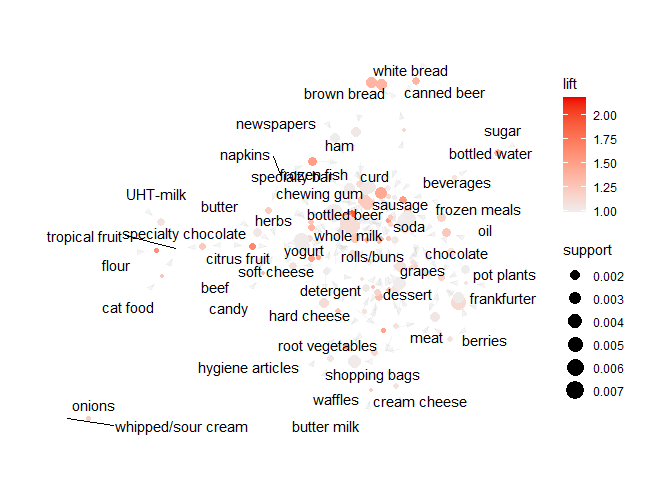

```r
plot(sort(basket_rules,by="lift"),method="graph",control=list(type="items"))
```

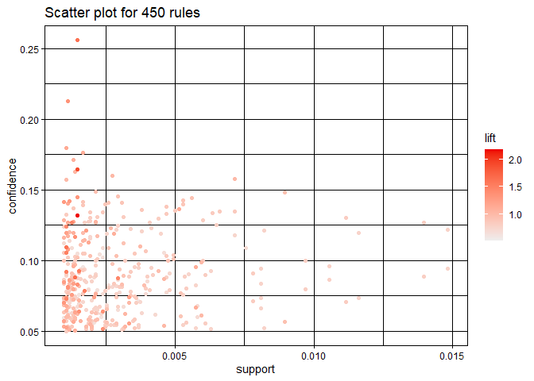

```r
plot(basket_rules, jitter = 0)
```

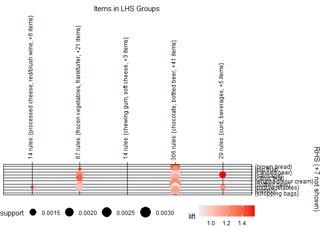

```r
plot(basket_rules, method = "grouped", control = list(k = 5))
```

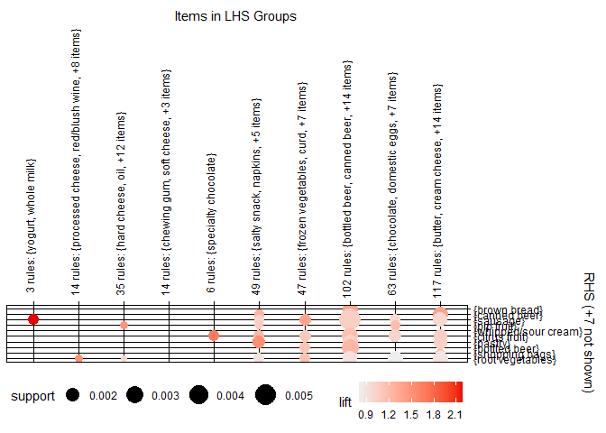

```r
plot(basket_rules, method = "grouped", control = list(k = 10))
```

## Grafik 10 aturan pertama

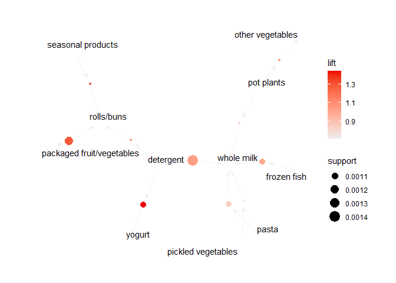

```r
plot(basket_rules[1:10], method="graph")
```

## Grafik 20 aturan pertama

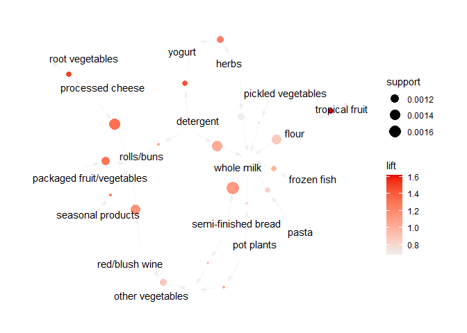

```r
plot(basket_rules[1:20], method="graph")
```

## Grafik 50 aturan pertama

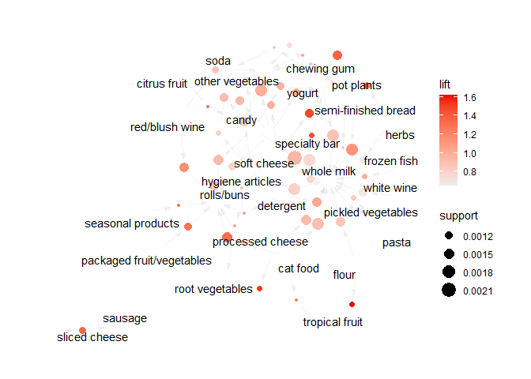

```r
plot(basket_rules[1:50], method="graph")
```

## Plot koordinat paralel

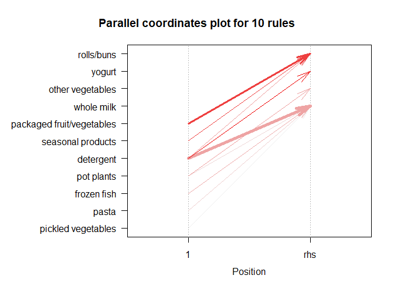

```r
plot(basket_rules[1:10], method="paracoord")
```

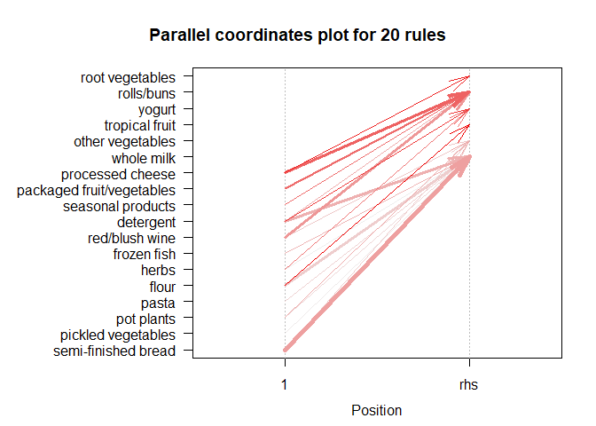

```r
plot(basket_rules[1:20], method="paracoord")
```

## Produk Yang Paling Sering Digunakan

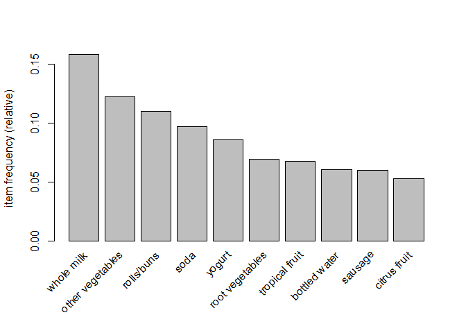

```r
itemFrequencyPlot(txn, topN = 10)
```

## Mengubah hiperparameter

```r
basket_rules2 <- apriori(txn, parameter = list(minlen=3, sup = 0.001, conf = 0.1, target="rules"))
```

```
## Apriori
##
## Parameter specification:
##  confidence minval smax arem  aval originalSupport maxtime support minlen
##         0.1    0.1    1 none FALSE            TRUE       5   0.001      3
##  maxlen target  ext
##      10  rules TRUE
##
## Algorithmic control:
##  filter tree heap memopt load sort verbose
##     0.1 TRUE TRUE  FALSE TRUE    2    TRUE
##
## Absolute minimum support count: 14
##
## set item appearances ...[0 item(s)] done [0.00s].
## set transactions ...[168 item(s), 14964 transaction(s)] done [0.01s].
## sorting and recoding items ... [149 item(s)] done [0.00s].
## creating transaction tree ... done [0.01s].
## checking subsets of size 1 2 3 4 done [0.00s].
## writing ... [17 rule(s)] done [0.00s].
## creating S4 object  ... done [0.00s].
```

```r
print(length(basket_rules2))
```

```
## [1] 17
```

```r
summary(basket_rules2)
```

```
## set of 17 rules
##
## rule length distribution (lhs + rhs):sizes
##  3
## 17
##
##    Min. 1st Qu.  Median    Mean 3rd Qu.    Max.
##       3       3       3       3       3       3
##
## summary of quality measures:
##     support           confidence        coverage             lift
##  Min.   :0.001002   Min.   :0.1018   Min.   :0.005346   Min.   :0.7214
##  1st Qu.:0.001136   1st Qu.:0.1172   1st Qu.:0.008086   1st Qu.:0.8897
##  Median :0.001136   Median :0.1269   Median :0.008955   Median :1.1081
##  Mean   :0.001207   Mean   :0.1437   Mean   :0.008821   Mean   :1.1794
##  3rd Qu.:0.001337   3rd Qu.:0.1642   3rd Qu.:0.010559   3rd Qu.:1.2297
##  Max.   :0.001470   Max.   :0.2558   Max.   :0.011160   Max.   :2.1831
##      count
##  Min.   :15.00
##  1st Qu.:17.00
##  Median :17.00
##  Mean   :18.06
##  3rd Qu.:20.00
##  Max.   :22.00
##
## mining info:
##  data ntransactions support confidence
##   txn         14964   0.001        0.1
##                                                                                          call
##  apriori(data = txn, parameter = list(minlen = 3, sup = 0.001, conf = 0.1, target = "rules"))
```

```r
inspect(basket_rules2)
```

```
##      lhs                               rhs                support
## [1]  {sausage, yogurt}              => {whole milk}       0.001470195
## [2]  {sausage, whole milk}          => {yogurt}           0.001470195
## [3]  {whole milk, yogurt}           => {sausage}          0.001470195
## [4]  {sausage, soda}                => {whole milk}       0.001069233
## [5]  {sausage, whole milk}          => {soda}             0.001069233
## [6]  {rolls/buns, sausage}          => {whole milk}       0.001136060
## [7]  {sausage, whole milk}          => {rolls/buns}       0.001136060
## [8]  {rolls/buns, yogurt}           => {whole milk}       0.001336541
## [9]  {whole milk, yogurt}           => {rolls/buns}       0.001336541
## [10] {other vegetables, yogurt}     => {whole milk}       0.001136060
## [11] {whole milk, yogurt}           => {other vegetables} 0.001136060
## [12] {rolls/buns, soda}             => {other vegetables} 0.001136060
## [13] {other vegetables, soda}       => {rolls/buns}       0.001136060
## [14] {other vegetables, rolls/buns} => {soda}             0.001136060
```

[output cut: 21 more lines]

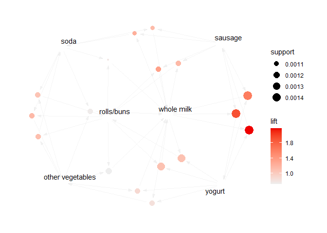

```r
plot(basket_rules2, method="graph")
```

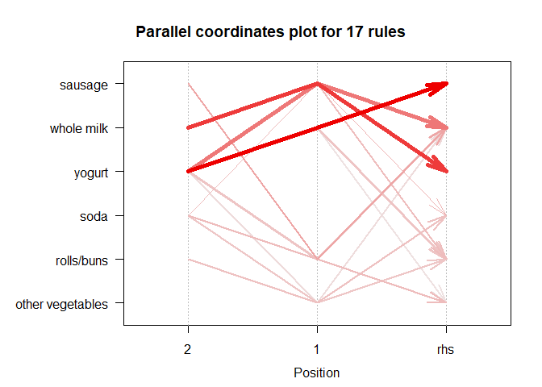

```r
plot(basket_rules2, method="paracoord")
```

# Referensi

1. https://www.kaggle.com/code/heeraldedhia/market-basket-analysis-using-apriori-algorithm/notebook
2. https://rpubs.com/Tantri_12345
3. https://github.com/Tantri12345/FP-Growth
4. https://www.kaggle.com/datasets/heeraldedhia/groceries-dataset?resource=download
5. https://gifadn.medium.com/market-basket-analisys-mba-dengan-menggunakan-datasets-groceries-di-r-62f63f0278c4